# Prediction of the accident possibility for carsharing company

# Content

1. Project Description
2. Connection to database and data loading
3. Data overview
4. Statistical analysis of accident factors
5. Building model of evaluation of driving risk
6. Analysis of accident factors impact
7. General Conclusion

# Project Description

Car sharing company would like to develop system for the evaluation of the risk of accident for the selected route. As risk company understands is possibility of accident with any damage to the vehicle. The system has to evaluate the risk level just after the booking of the car by client. Current task for the company is to understand is it possible to predict the possibility of accident based on the historical data of one of the regions where company operated.

Main tasks are following:

1) To connect to database and import data;

2) Prepare and analyze the data.

3) Set the tasks to work team.

4) Train the models and select the best one;

5) Find the key factor leading to possibility of accident;

6) Propose the tools for reduction of possibility of accident.

# Connection to database and data loading

```python
import pandas as pd
import matplotlib.pyplot as plt
import numpy as np
import seaborn as sns
from sqlalchemy import create_engine
import matplotlib.pyplot as plt
import torch
import torch.nn as nn
from sklearn.preprocessing import OneHotEncoder,StandardScaler, MinMaxScaler
from sklearn.model_selection import train_test_split
from sklearn.tree import DecisionTreeClassifier
from sklearn.ensemble import RandomForestClassifier
from sklearn.metrics import roc_auc_score
from sklearn.metrics import roc_curve
from sklearn.model_selection import RandomizedSearchCV
from sklearn.metrics import precision_recall_curve
```

```python
import warnings
warnings.simplefilter(action='ignore', category=FutureWarning)
warnings.simplefilter(action='ignore', category=DeprecationWarning)
warnings.simplefilter(action='ignore', category=RuntimeWarning)
```

```python
db_config = {
'user': '******', # имя пользователя,
'pwd': '*****', # пароль,
'host': '****',
'port': ****, # порт подключения,
'db': '****' # название базы данных,
}
```

```python
connection_string = 'postgresql://{}:{}@{}:{}/{}'.format(
    db_config['user'],
    db_config['pwd'],
    db_config['host'],
    db_config['port'],
    db_config['db'],
)
```

```python
engine = create_engine(connection_string)
```

```python
query = '''
SELECT *
FROM Parties
'''

parties_df = pd.read_sql_query(query, con=engine)
```

```python
query = '''
SELECT *
FROM collisions
'''

collisions_df = pd.read_sql_query(query, con=engine)
```

```python
query = '''
SELECT *
FROM Vehicles
'''

vehicles_df = pd.read_sql_query(query, con=engine)
```

```python
query = '''
SELECT *
FROM case_ids
'''

case_ids_df = pd.read_sql_query(query, con=engine)
```

# Data overview

```python
parties_df.info()
```

```
<class 'pandas.core.frame.DataFrame'>
RangeIndex: 2752408 entries, 0 to 2752407
Data columns (total 9 columns):
 #   Column               Dtype
---  ------               -----
 0   id                   int64
 1   case_id              object
 2   party_number         int64
 3   party_type           object
 4   at_fault             int64
 5   insurance_premium    float64
 6   party_sobriety       object
 7   party_drug_physical  object
 8   cellphone_in_use     float64
dtypes: float64(2), int64(3), object(4)
memory usage: 189.0+ MB
```

```python
parties_df.head()
```

|  | id | case_id | party_number | party_type | at_fault | insurance_premium | party_sobriety | party_drug_physical | cellphone_in_use |
| --- | --- | --- | --- | --- | --- | --- | --- | --- | --- |
| 0 | 22 | 3899454 | 1 | road signs | 1 | 29.0 | had not been drinking | None | 0.0 |
| 1 | 23 | 3899454 | 2 | road signs | 0 | 7.0 | had not been drinking | None | 0.0 |
| 2 | 29 | 3899462 | 2 | car | 0 | 21.0 | had not been drinking | None | 0.0 |
| 3 | 31 | 3899465 | 2 | road signs | 0 | 24.0 | had not been drinking | None | 0.0 |
| 4 | 41 | 3899478 | 2 | road bumper | 0 | NaN | not applicable | not applicable | 0.0 |

```python
collisions_df.info()
```

```
<class 'pandas.core.frame.DataFrame'>
RangeIndex: 1400000 entries, 0 to 1399999
Data columns (total 20 columns):
 #   Column                       Non-Null Count    Dtype
---  ------                       --------------    -----
 0   case_id                      1400000 non-null  object
 1   county_city_location         1400000 non-null  object
 2   county_location              1400000 non-null  object
 3   distance                     1400000 non-null  float64
 4   direction                    1059358 non-null  object
 5   intersection                 1387781 non-null  float64
 6   weather_1                    1392741 non-null  object
 7   location_type                518779 non-null   object
 8   collision_damage             1400000 non-null  object
 9   party_count                  1400000 non-null  int64
 10  primary_collision_factor     1391834 non-null  object
 11  pcf_violation_category       1372046 non-null  object
 12  type_of_collision            1388176 non-null  object
 13  motor_vehicle_involved_with  1393181 non-null  object
 14  road_surface                 1386907 non-null  object
 15  road_condition_1             1388012 non-null  object
 16  lighting                     1391407 non-null  object
 17  control_device               1391593 non-null  object
 18  collision_date               1400000 non-null  object
 19  collision_time               1387692 non-null  object
dtypes: float64(2), int64(1), object(17)
memory usage: 213.6+ MB
```

```python
collisions_df.head()
```

|  | case_id | county_city_location | county_location | distance | direction | intersection | weather_1 | location_type | collision_damage | party_count | primary_collision_factor | pcf_violation_category | type_of_collision | motor_vehicle_involved_with | road_surface | road_condition_1 | lighting | control_device | collision_date | collision_time |
| --- | --- | --- | --- | --- | --- | --- | --- | --- | --- | --- | --- | --- | --- | --- | --- | --- | --- | --- | --- | --- |
| 0 | 4083072 | 1942 | los angeles | 528.0 | north | 0.0 | cloudy | highway | small damage | 2 | vehicle code violation | unsafe lane change | sideswipe | other motor vehicle | wet | normal | daylight | none | 2009-01-22 | 07:25:00 |
| 1 | 4083075 | 4313 | santa clara | 0.0 | None | 1.0 | clear | None | small damage | 1 | vehicle code violation | improper passing | hit object | fixed object | dry | normal | dark with street lights | functioning | 2009-01-03 | 02:26:00 |
| 2 | 4083073 | 0109 | alameda | 0.0 | None | 1.0 | clear | None | scratch | 2 | vehicle code violation | improper turning | broadside | other motor vehicle | dry | normal | dark with street lights | functioning | 2009-01-11 | 03:32:00 |
| 3 | 4083077 | 0109 | alameda | 0.0 | None | 1.0 | clear | None | scratch | 2 | vehicle code violation | automobile right of way | broadside | other motor vehicle | dry | normal | daylight | functioning | 2009-01-11 | 10:35:00 |
| 4 | 4083087 | 4313 | santa clara | 0.0 | None | 1.0 | clear | None | scratch | 2 | vehicle code violation | speeding | rear end | other motor vehicle | dry | None | dark with street lights | functioning | 2009-01-02 | 22:43:00 |

```python
vehicles_df.info()
```

```
<class 'pandas.core.frame.DataFrame'>
RangeIndex: 1021234 entries, 0 to 1021233
Data columns (total 6 columns):
 #   Column                Non-Null Count    Dtype
---  ------                --------------    -----
 0   id                    1021234 non-null  int64
 1   case_id               1021234 non-null  object
 2   party_number          1021234 non-null  int64
 3   vehicle_type          1021234 non-null  object
 4   vehicle_transmission  997575 non-null   object
 5   vehicle_age           996652 non-null   float64
dtypes: float64(1), int64(2), object(3)
memory usage: 46.7+ MB
```

```python
vehicles_df.head()
```

|  | id | case_id | party_number | vehicle_type | vehicle_transmission | vehicle_age |
| --- | --- | --- | --- | --- | --- | --- |
| 0 | 1175713 | 5305032 | 2 | sedan | manual | 3.0 |
| 1 | 1 | 3858022 | 1 | sedan | auto | 3.0 |
| 2 | 1175712 | 5305030 | 1 | sedan | auto | 3.0 |
| 3 | 1175717 | 5305033 | 3 | sedan | auto | 5.0 |
| 4 | 1175722 | 5305034 | 2 | sedan | auto | 5.0 |

```python
del vehicles_df
del parties_df
del collisions_df
```

**Conclusion**

1) Parties_df has 2 752 408 rows and 9 columns;

# Statistical analysis of accident factors

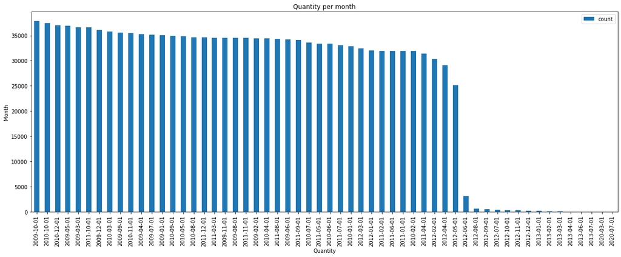

```python
# display the quantity of accidents per month
query = '''
SELECT COUNT(case_id), DATE(DATE_TRUNC('month',collision_date)) AS month_date
FROM collisions
GROUP BY DATE(DATE_TRUNC('month',collision_date))
ORDER BY COUNT(case_id) DESC
'''

month_df = pd.read_sql_query(query, con=engine)
month_df.head()
month_df.plot(kind='bar',y = 'count', x = 'month_date', figsize =(20,7),title = 'Quantity per month')
plt.xlabel('Quantity')
plt.ylabel('Month')
plt.show()
```

**Tasks to work team:**

1) To analyze the level of damage to vehicles, based on the surface condition in the moment of accident (to join collisions и parties)

2) Find the most often reasons of accidents (table parties)

3) Analyze in what period of the day is the highest quantity of accidents with fatal damage happens.

4) Does the type of gearbox affect on the quantity of accidents .

5) Analysis of relation of level of damage and drivers sobriety.

6) Which region has and in which month has the highest quantity of accidents.

*the numbers 4 and 5 to be analyzed below*

**Analysis of relation of level of damage and drivers sbriety**

```python
# query to get the statistic on not sober drivers
query = '''
SELECT c.collision_damage,COUNT(c.case_id)
  FROM collisions AS c
  INNER JOIN Parties AS p
       ON c.case_id = p.case_id
  WHERE p.party_sobriety LIKE '%%had been drinking%%'
 GROUP BY c.collision_damage
 ORDER BY COUNT(c.case_id) DESC
'''

dmg_drunk_df = pd.read_sql_query(query, con=engine)
dmg_drunk_df['percentage'] = round(dmg_drunk_df['count'] / dmg_drunk_df['count'].sum()*100,0)
dmg_drunk_df
```

|  | collision_damage | count | percentage |
| --- | --- | --- | --- |
| 0 | small damage | 87228 | 58.0 |
| 1 | middle damage | 27876 | 18.0 |
| 2 | scratch | 23937 | 16.0 |
| 3 | severe damage | 7956 | 5.0 |
| 4 | fatal | 4485 | 3.0 |

```python
# query to get the statistic on sober drivers
query = '''
SELECT c.collision_damage,COUNT(c.case_id)
  FROM collisions AS c
  FULL OUTER JOIN Parties AS p
       ON c.case_id = p.case_id
  WHERE p.party_sobriety NOT LIKE '%%had not been drinking%%'
 GROUP BY c.collision_damage
 ORDER BY COUNT(c.case_id) DESC
'''

dmg_sober_df = pd.read_sql_query(query, con=engine)
dmg_sober_df['percentage'] = round(dmg_sober_df['count'] / dmg_sober_df['count'].sum()*100,0)
dmg_sober_df
```

|  | collision_damage | count | percentage |
| --- | --- | --- | --- |
| 0 | small damage | 394814 | 71.0 |
| 1 | scratch | 79614 | 14.0 |
| 2 | middle damage | 57497 | 10.0 |
| 3 | severe damage | 14771 | 3.0 |
| 4 | fatal | 7030 | 1.0 |

```
  collision_damage  percentage_drunk  percentage_sober
0     small damage              58.0              71.0
1          scratch              18.0              14.0
2    middle damage              16.0              10.0
3    severe damage               5.0               3.0
4            fatal               3.0               1.0
```

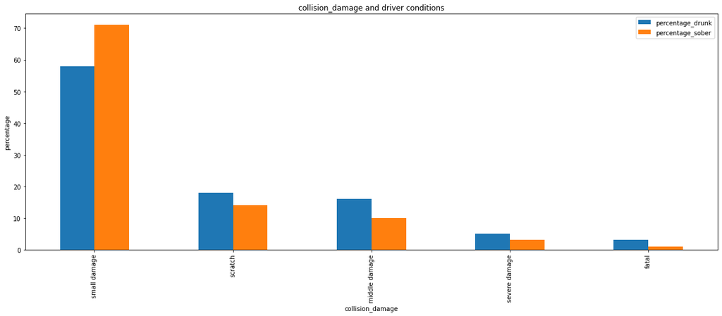

```python
# Comparison of sober and drunk driver statistic
sober_drunk = pd.DataFrame(dmg_sober_df['collision_damage'])
sober_drunk['percentage_drunk'] = dmg_drunk_df['percentage']
sober_drunk['percentage_sober'] = dmg_sober_df['percentage']
print(sober_drunk)
sober_drunk.plot.bar(x='collision_damage', figsize =(20,7),title = 'collision_damage and driver conditions')
plt.xlabel('collision_damage')
plt.ylabel('percentage')
```

```python
sober_drunk['percentage_sober_drunk'] = round(( sober_drunk['percentage_drunk']/sober_drunk['percentage_sober']-1)*100,0)
```

```python
sober_drunk
```

|  | collision_damage | percentage_drunk | percentage_sober | percentage_sober_drunk |
| --- | --- | --- | --- | --- |
| 0 | small damage | 58.0 | 71.0 | -18.0 |
| 1 | scratch | 18.0 | 14.0 | 29.0 |
| 2 | middle damage | 16.0 | 10.0 | 60.0 |
| 3 | severe damage | 5.0 | 3.0 | 67.0 |
| 4 | fatal | 3.0 | 1.0 | 200.0 |

**Conclusion**

The overall conclusion is that accidents with severe and fayal damage happens times more often when driver is drunk compare to sober drivers, but total quantity of accidents in sober condition times higher.

**Main conclusion do not drink when driving**

**Analysis of relation of gearbox type on quantity of accidents.**

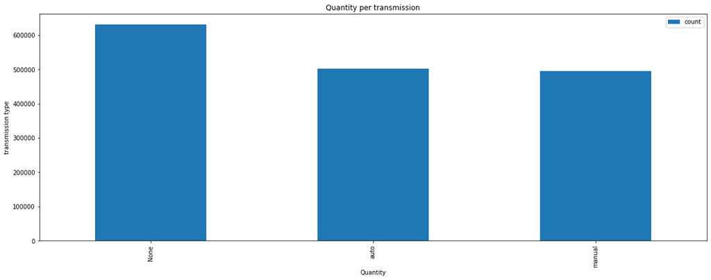

```python
query = '''
SELECT COUNT(s.case_id), v.vehicle_transmission AS transmission_type
  FROM collisions AS s
       FULL OUTER JOIN Vehicles AS v
       ON s.case_id = v.case_id
GROUP BY v.vehicle_transmission
ORDER BY COUNT(s.case_id) DESC
'''

kpp_df = pd.read_sql_query(query, con=engine)
kpp_df.head()
kpp_df.plot(kind='bar',y = 'count', x = 'transmission_type', figsize =(20,7),title = 'Quantity per transmission')
plt.xlabel('Quantity')
plt.ylabel('transmission type')
plt.show()
```

```python
del kpp_df
del dmg_sober_df
```

**Conclusion**

Based on the analysis the conclusion is following - type of gearbox has no affect on quantity of accidents.

**Creating a table with all features for statistic analysis**

```python
query = '''
SELECT *
  FROM collisions AS s
       INNER JOIN Vehicles AS v
       ON s.case_id = v.case_id
       INNER JOIN Parties AS p
       ON s.case_id = p.case_id
'''

total_df = pd.read_sql_query(query, con=engine)
total_df.head()
```

|  | case_id | county_city_location | county_location | distance | direction | intersection | weather_1 | location_type | collision_damage | party_count | ... | vehicle_age | id | case_id | party_number | party_type | at_fault | insurance_premium | party_sobriety | party_drug_physical | cellphone_in_use |
| --- | --- | --- | --- | --- | --- | --- | --- | --- | --- | --- | --- | --- | --- | --- | --- | --- | --- | --- | --- | --- | --- |
| 0 | 4014984 | 3631 | san bernardino | 0.0 | None | 1.0 | clear | highway | fatal | 2 | ... | 10.0 | 2532 | 4014984 | 1 | road signs | 1 | 63.0 | had not been drinking | under drug influence | NaN |
| 1 | 4027576 | 3711 | san diego | 350.0 | south | 0.0 | clear | None | middle damage | 1 | ... | 1.0 | 4456 | 4027576 | 1 | building | 1 | 10.0 | had not been drinking | None | 0.0 |
| 2 | 4033928 | 2002 | madera | 55.0 | west | 0.0 | cloudy | highway | small damage | 2 | ... | 3.0 | 7194 | 4033928 | 2 | road bumper | 0 | NaN | not applicable | not applicable | NaN |
| 3 | 4035554 | 1005 | fresno | 0.0 | None | 1.0 | clear | ramp | scratch | 2 | ... | 7.0 | 8830 | 4035554 | 1 | building | 1 | 46.0 | had not been drinking | None | 0.0 |
| 4 | 4035554 | 1005 | fresno | 0.0 | None | 1.0 | clear | ramp | scratch | 2 | ... | 1.0 | 8830 | 4035554 | 1 | building | 1 | 46.0 | had not been drinking | None | 0.0 |

5 rows × 35 columns

```python
total_df.info()
```

```
<class 'pandas.core.frame.DataFrame'>
RangeIndex: 2194043 entries, 0 to 2194042
Data columns (total 35 columns):
 #   Column                       Dtype
---  ------                       -----
 0   case_id                      object
 1   county_city_location         object
 2   county_location              object
 3   distance                     float64
 4   direction                    object
 5   intersection                 float64
 6   weather_1                    object
 7   location_type                object
 8   collision_damage             object
 9   party_count                  int64
```

[output cut: 27 more lines]

```python
# deletion of useless columns
total_df = total_df.drop(columns = ['id','case_id'])
total_df.info()
```

```
<class 'pandas.core.frame.DataFrame'>
RangeIndex: 2194043 entries, 0 to 2194042
Data columns (total 30 columns):
 #   Column                       Dtype
---  ------                       -----
 0   county_city_location         object
 1   county_location              object
 2   distance                     float64
 3   direction                    object
 4   intersection                 float64
 5   weather_1                    object
 6   location_type                object
 7   collision_damage             object
 8   party_count                  int64
 9   primary_collision_factor     object
```

[output cut: 22 more lines]

```python
# change of datatype of column county_city_location
total_df['county_city_location'] = total_df['county_city_location'].astype('float64')
```

```python
# selection of categorical and numeric columns
numeric_col = list(total_df.select_dtypes(include=['int64', 'float64']).columns[:])
categorical_col = list(total_df.select_dtypes(include=['object']).columns[:])
categorical_col.remove('collision_date')
categorical_col.remove('collision_time')
dt_cols = ['collision_date','collision_time']
print('Numerical columns:', numeric_col,'\n')
print('Categorical columns:','\n',categorical_col,'\n')
print('Date time columns:','\n',dt_cols)
```

[output not shown]

```python
# function for plotting
def plot_bar_func (column):
    print(total_df.groupby(column)['at_fault'].count().sort_values(ascending=False))
    total_df.groupby(column)['at_fault'].count().sort_values(ascending=False).plot(kind='bar',figsize = (20,10))
    plt.title(column)
    plt.xlabel(column)
    plt.ylabel('Quantity')
    plt.show()
```

```
county_location
los angeles        706419
orange             205025
san diego          154835
san bernardino     117320
riverside          110455
sacramento         100013
alameda             90142
santa clara         82024
ventura             47227
contra costa        42282
kern                41802
san joaquin         41714
fresno              41378
san francisco       40484
san mateo           34695
stanislaus          29903
sonoma              26680
santa barbara       24939
solano              21888
placer              20961
tulare              20897
monterey            18786
merced              14607
santa cruz          14428
san luis obispo     13297
marin               13245
shasta              10728
butte                9131
yolo                 8800
napa                 7810
madera               7774
humboldt             7693
el dorado            7547
kings                6809
sutter               5450
imperial             5292
nevada               4987
mendocino            4305
tuolumne             3457
yuba                 3254
tehama               3155
lake                 2908
san benito           2585
amador               2456
calaveras            2309
siskiyou             1831
del norte            1426
colusa               1239
glenn                1221
inyo                 1209
lassen               1143
mono                  881
mariposa              857
plumas                819
trinity               670
alpine                351
modoc                 316
sierra                184
Name: at_fault, dtype: int64
```

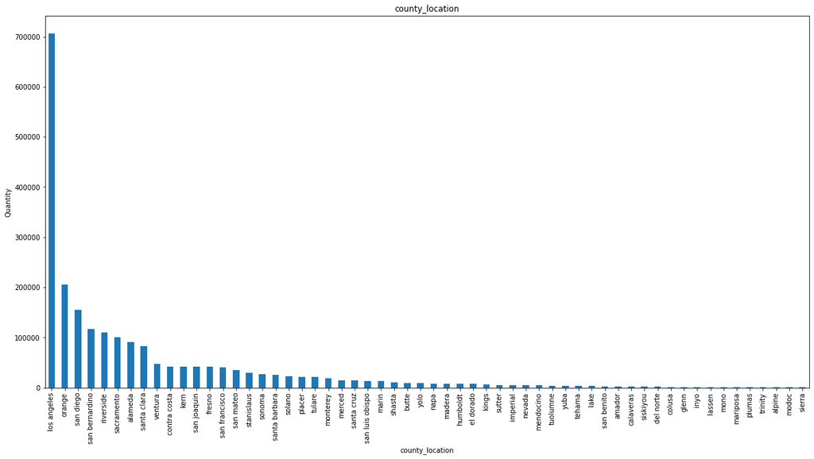

```
direction
south    435473
north    432081
east     355717
west     355433
Name: at_fault, dtype: int64
```

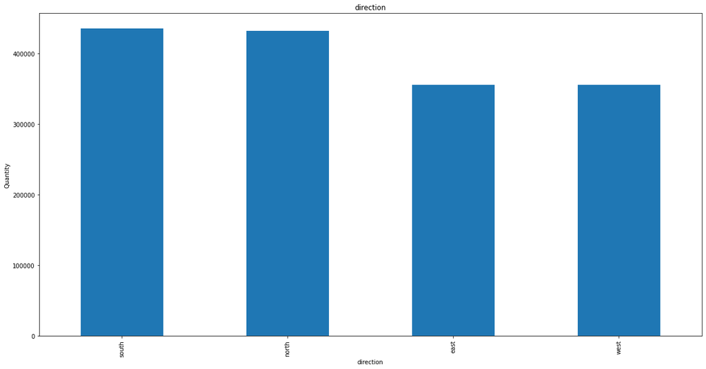

```
weather_1
clear      1792328
cloudy      300615
raining      77836
fog           7742
snowing       3624
other         1357
wind           596
Name: at_fault, dtype: int64
```

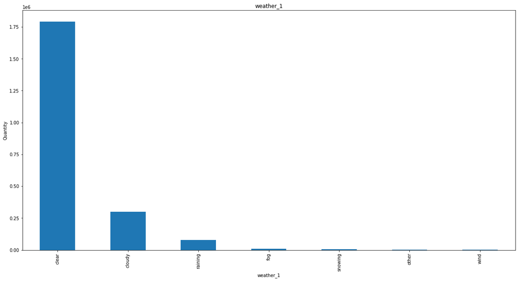

```
location_type
highway         708497
ramp            102565
intersection     47820
Name: at_fault, dtype: int64
```

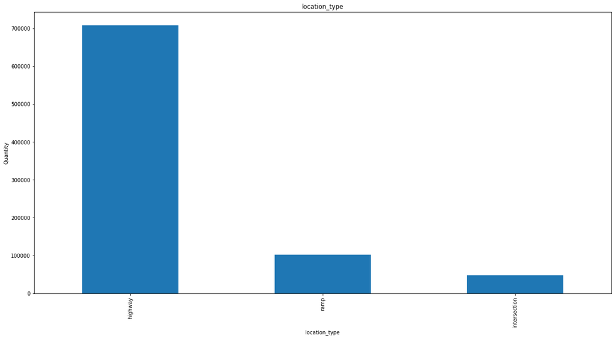

```
collision_damage
scratch          1026384
small damage      595087
middle damage     455738
severe damage      84894
fatal              31940
Name: at_fault, dtype: int64
```

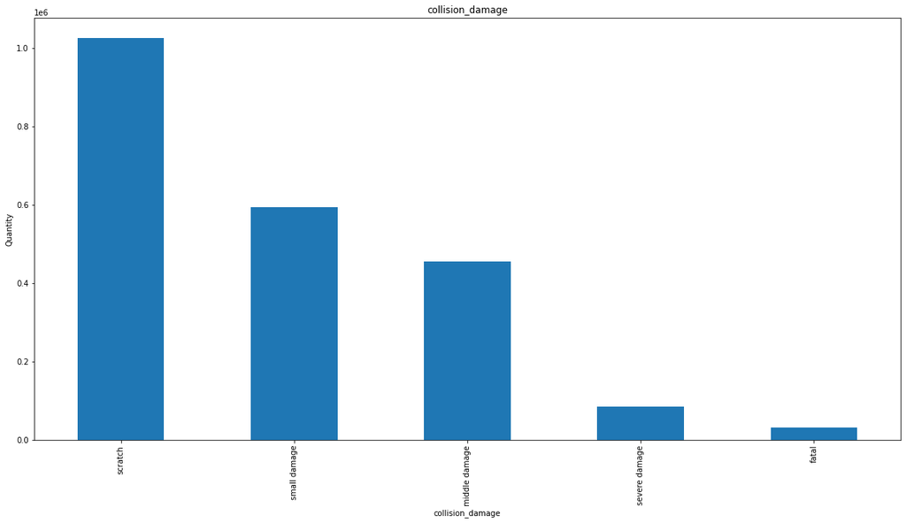

```
primary_collision_factor
vehicle code violation    2112950
unknown                     36365
other than driver           26526
other improper driving       8921
fell asleep                   111
Name: at_fault, dtype: int64
```

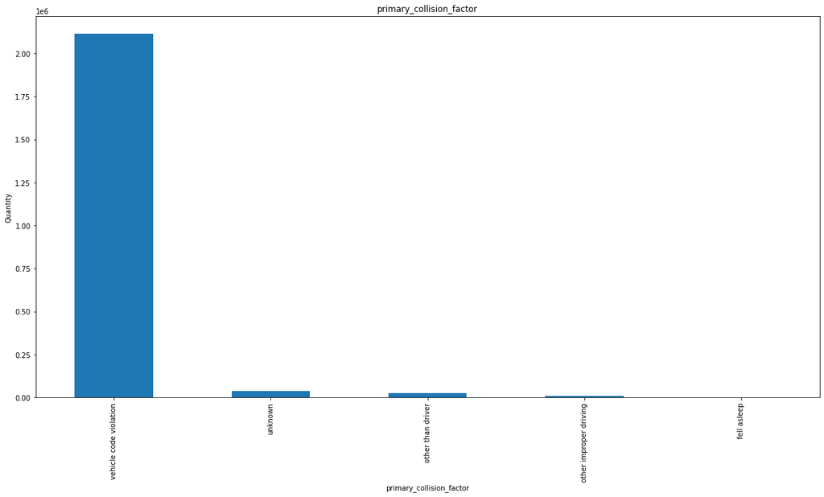

```
pcf_violation_category
speeding                             815444
automobile right of way              318257
improper turning                     215350
traffic signals and signs            164629
dui                                  142711
unsafe lane change                   137691
following too closely                 58733
wrong side of road                    57217
unsafe starting or backing            53540
pedestrian right of way               38795
unknown                               38430
pedestrian violation                  38186
other than driver (or pedestrian)     26526
other hazardous violation             21396
improper passing                      16174
other improper driving                 8921
other equipment                        1811
impeding traffic                       1694
hazardous parking                      1276
lights                                  455
brakes                                  372
fell asleep                             111
pedestrian dui                            4
Name: at_fault, dtype: int64
```

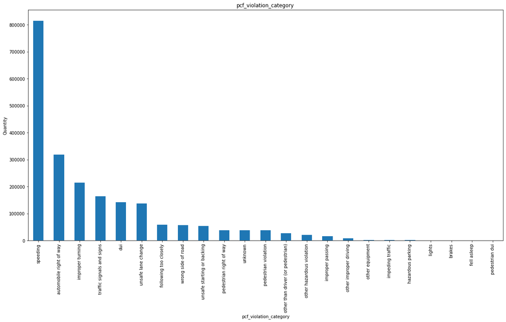

```
type_of_collision
rear end      927529
broadside     535425
sideswipe     288132
other         146999
hit object    131288
head-on       113380
overturned     35667
Name: at_fault, dtype: int64
```

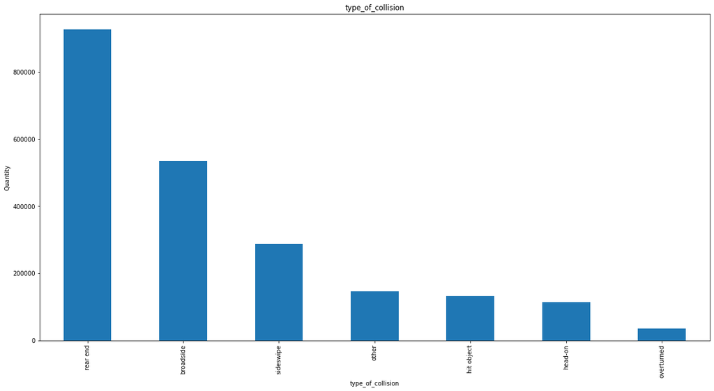

```
motor_vehicle_involved_with
other motor vehicle               1719087
other object                       131762
fixed object                       122610
bicycle                             89665
parked motor vehicle                62292
non-collision                       37920
motor vehicle on other roadway      19518
animal                               2762
train                                 686
Name: at_fault, dtype: int64
```

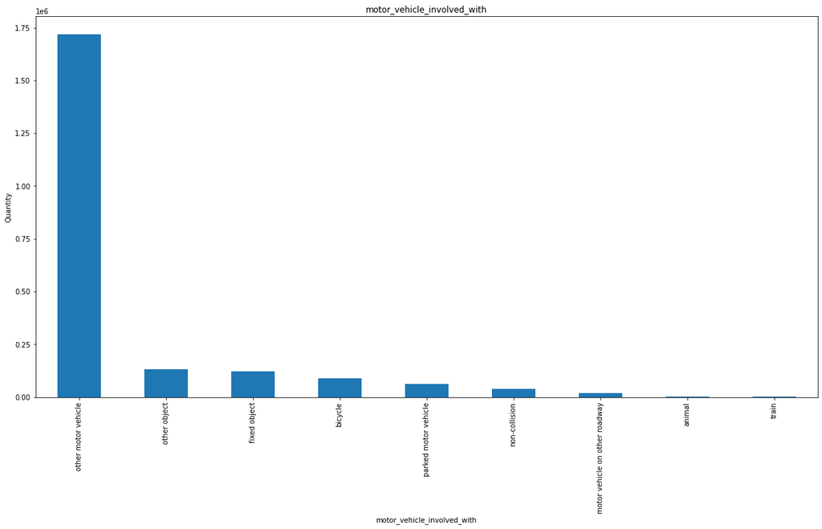

```
road_surface
dry         1983149
wet          182005
snowy          8736
slippery       1596
Name: at_fault, dtype: int64
```

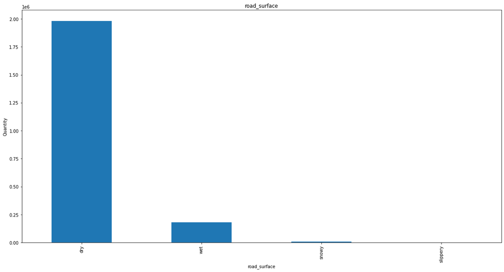

```
road_condition_1
normal            2112501
construction        35337
holes                8348
other                7631
obstruction          7327
loose material       2954
reduced width        1649
flooded              1250
Name: at_fault, dtype: int64
```

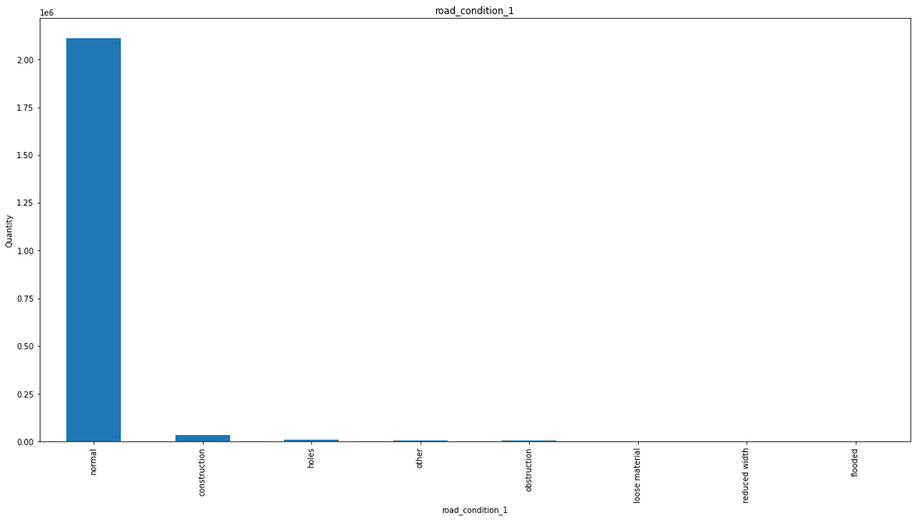

```
lighting
daylight                                   1574429
dark with street lights                     407141
dark with no street lights                  125922
dusk or dawn                                 69753
dark with street lights not functioning       6100
Name: at_fault, dtype: int64
```

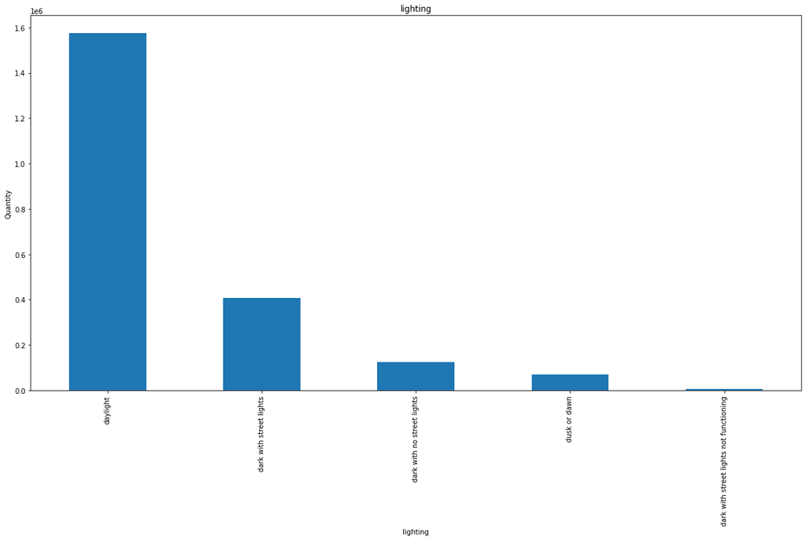

```
control_device
none               1313657
functioning         862091
not functioning       6424
obscured              1136
Name: at_fault, dtype: int64
```

[6 more figures not shown]

```python
# Plotting the info of categorical columns
for i in categorical_col[:]:
    plot_bar_func(i)
```